# problema1-v2

1. O professor Hans Rosling cita em sua apresentação vários exemplos de como dados relativos às nações podem se correlacionar e, partindo dos resultados gerados, tirar conclusões mais precisas acerca de temas como países ricos e pobres, taxas de mortalidade, expectativa de vida, etc. O primeiro exemplo citado na apresentação demonstra uma motivação para se realizar tais experimentos, tendo em vista que sem esse tipo de análise, as ideias consideradas seriam puramente preconcebidas e com pouco embasamento para assegurar qualquer informação. Neste exemplo, o professor questiona seus alunos dentre pares de países, quais aqueles que apresentam maior taxa de mortalidade. Os alunos obtiveram uma taxa de acerto baixa, pois responderam baseados apenas em conceitos preconcebidos acerca dos países em questão. O proximo exemplo diz respeito a um questionamento sobre o “mundo ocidental” e “terceiro mundo”. A ideia inicial era de países com baixa taxa de fertilidade possuiam altas expectativas de vida, enquanto os que tivessem uma taxa de fertilidade alta, teriam baixa expectativa de vida ( Western World: Long life, short family. Third World: Short Life, big family). O problema segue com uma análise da taxa de fertilidade e expectativa de vida dos países dentre as décadas de 60 até os anos 2000. O programa mostra que os países industrializados na década de 60 possuíam pequenas famílias e altas expectativas de vida, enquanto os considerados de terceiro mundo estavam com baixa taxa de expectativa de vida e alta taxa de fertilidade. Com o passar dos anos, os países de terceiro mundo começam a se aproximar dos países ricos, diminuindo suas taxas de fertilidade e aumentando a expectativa de vida. Um destaque para a China, que apresentou um desenvolvimento mais acelerado que os outros países e outro destaque seria a epidemia do vírus HIV na década de 90 que ocorreu em vários países da África. A mesma análise segue com um comparativo entre Estados Unidos e Vietnã e mostra que, mesmo com todas as mortes durante a guerra no Vietnã, houve uma melhoria na expectativa do país. Outro ponto importante ressaltado por Hans é o fato da mudança economica na Ásia ser precedida por mudanças sociais, podendo ser confirmado a partir da análise dos dados que coincide com os fatos históricos ocorridos no continente. A próxima análise é em relação a distribuição de renda no mundo. Portanto, podemos concluir pela apresentação que, de acordo com as pesquisas e análises dos dados mostrados no vídeo, podemos ser levados a pensar de forma errônea em um contexto mais específico por conta de uma imagem definida em um contexto geral. A análise de correlação entre os dados aparece como um forte fator na formação e previsão de fenômenos, dando mais confiança a um determinado estudo por conseguir resultados mais precisos e confiáveis.
2. Aqui tratamos de analisar os atributos Salario.Bruto, UF, Regiao, Cidade, função e expertise. Para inicar a análise, a função summary() nos ajuda a visualizar valores como número de profissionais envolvidos na pesquisa, valor máximo e mínimo dos salários, jornada de trabalho, tempo de empresa, experiência profissional, número de profissionais em determinada região, cursos nos quais os profissionais se formaram, quem possui pós-graduação ou algum tipo de certificação, cargos, etc.

```r
dados <- read.csv("salarios-ti-regioes.csv");
summary(dados);
```

```
##        X                     Cidade         UF     Salario.Bruto
##  Min.   :  1.00   Belo Horizonte:39   MG     :47   Min.   :  500
##  1st Qu.: 41.25   Rio de Janeiro:16   SP     :25   1st Qu.: 2281
##  Median : 81.50   Brasília      :12   RJ     :17   Median : 3583
##  Mean   : 81.50   Campinas      :11   DF     :16   Mean   : 4233
##  3rd Qu.:121.75   Recife        :10   PE     :10   3rd Qu.: 5332
##  Max.   :162.00   São Paulo     : 9   BA     : 9   Max.   :42120
##                   (Other)       :65   (Other):38
##  Horas.Diarias   Tempo.de.Empresa Experiencia.Profissional
##  Min.   :4.000   Min.   : 0.000   Min.   : 0.00
##  1st Qu.:8.000   1st Qu.: 0.600   1st Qu.: 3.00
##  Median :8.000   Median : 1.080   Median : 5.00
##  Mean   :7.886   Mean   : 2.076   Mean   : 5.53
##  3rd Qu.:8.000   3rd Qu.: 2.958   3rd Qu.: 7.00
##  Max.   :9.000   Max.   :12.000   Max.   :32.00
##
##    Iniciativa.Privada.ou.Concursado
##                    :  8
##  Concursado        : 36
##  Iniciativa Privada:118
##
##
##
##
##                                 Cargo
##  Desenvolvimento Java              :  7
##  Analista de Sistemas              :  6
##  Desenvolvedor Java                :  6
##                                    :  3
##  Analista de Sistemas/Desenvolvedor:  3
##  Desenvolvedor                     :  3
##  (Other)                           :134
##                                Formacao  Pos.Graduacao.ou.Certificacao
##                                    :29   Mode :logical
##  Ciência da Computação             :23   FALSE:82
##  Bacharel em Ciência da Computação :19   TRUE :80
##  Graduação em Ciência da Computação: 6   NA's :0
##  Sistemas de Informação            : 5
##  Engenharia de Computação          : 4
##  (Other)                           :76
##           Regiao
##  Centro-oeste:19
##  Nordeste    :34
##  Norte       : 2
##  Sudeste     :92
##  Sul         :13
##  NA's        : 2
##
```

Aqui podemos observar que o maior número de observações ocorre no estado de Minas Gerais, seguido de outras regiões como São Paulo, Rio de Janeiro e Distrito Federal.

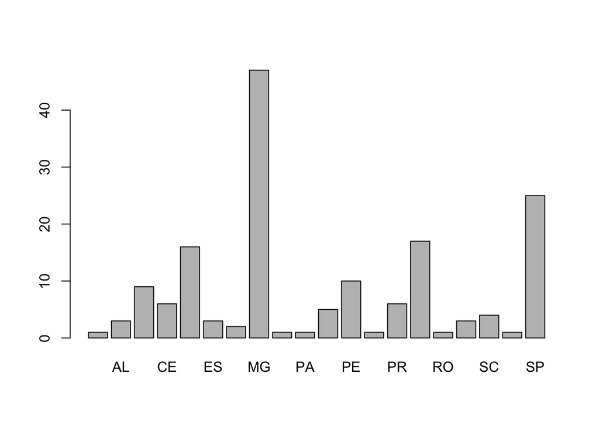

```r
dados <- read.csv("salarios-ti-regioes.csv");
plot(dados$UF)
```

O gráfico das regiões mostra que a maior concentração de profissionais ocorro no Sudeste, seguido do Nordeste (um ponto que pode ser curioso para muitos que desconhecem o potencial desta região no mercado de TI).

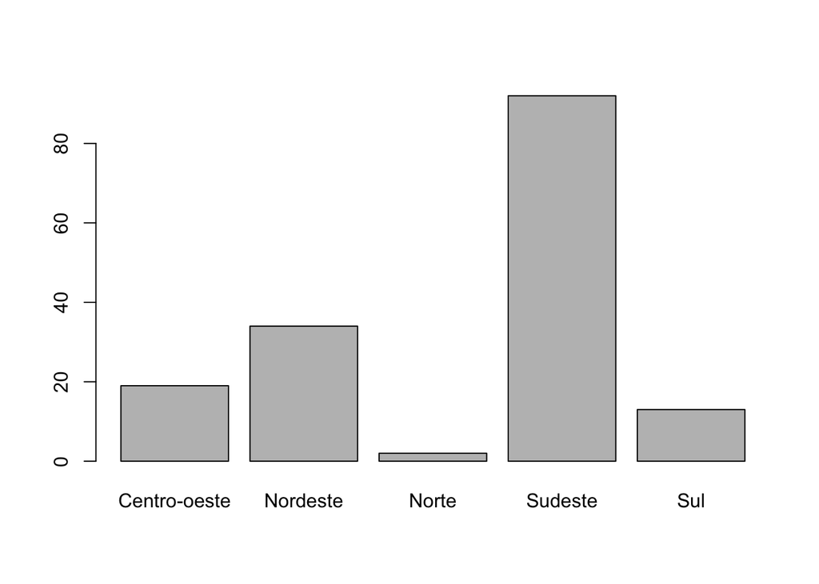

```r
dados <- read.csv("salarios-ti-regioes.csv");
plot(dados$Regiao)
```

3. Pelo histograma podemos verificar que cerca de 120 profissionais recebem um salário numa faixa que varia de 0 a 5000, enquanto 40 profissionais recebem entre 5000 e 10000.

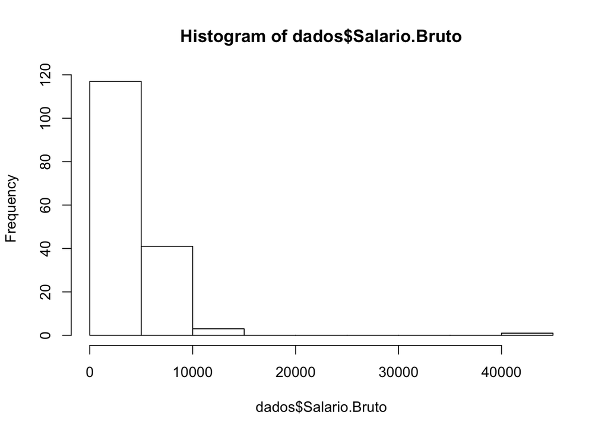

```r
dados <- read.csv("salarios-ti-regioes.csv");
hist(dados$Salario.Bruto) ;
```

Pelo boxplot, podemos verificar 4 outliers. 3 deles se econtram logo acima do limite superior, numa faixa entre 10000 e 20000. O quarto outlier se encontra muito acima de todos os salários, no valor de 42120. Ainda assim, segundo o boxplot, os salários se encontram bem concentrados, com média (4233) e mediana (3583) bem próximos.

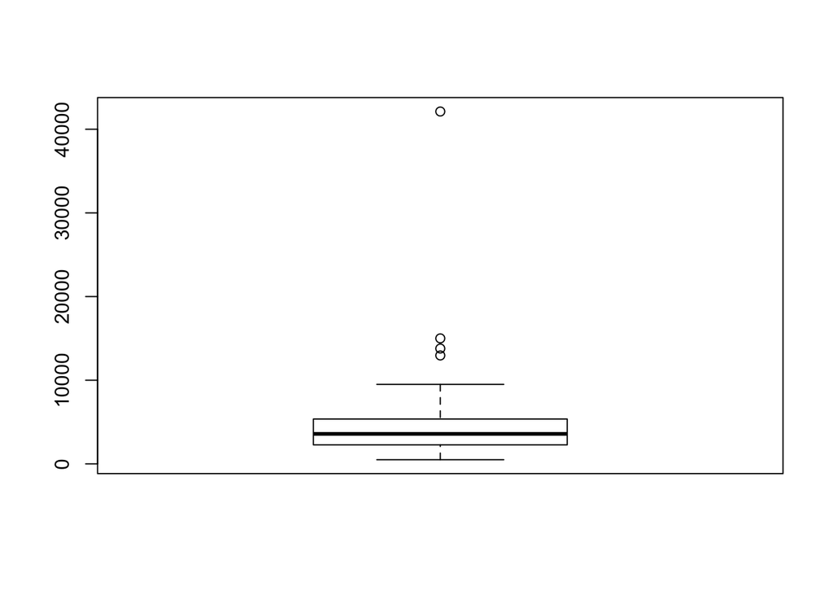

```r
dados <- read.csv("salarios-ti-regioes.csv");
boxplot(dados$Salario.Bruto);
```

```r
dados <- read.csv("salarios-ti-regioes.csv");
head(dados)
```

```
##   X         Cidade UF Salario.Bruto Horas.Diarias Tempo.de.Empresa
## 1 1 Campina Grande PB         42120             6              5.0
## 2 2       Brasília DF         15000             8             12.0
## 3 3         Recife PE         13787             7              1.0
## 4 4       Brasília DF         12960             7              0.5
## 5 5 Belo Horizonte MG          9500             8              3.0
## 6 6       Campinas SP          8500             8              1.0
##   Experiencia.Profissional Iniciativa.Privada.ou.Concursado
## 1                        7               Iniciativa Privada
## 2                       12                       Concursado
## 3                        5                       Concursado
## 4                       10                       Concursado
## 5                        2                       Concursado
## 6                        7               Iniciativa Privada
##                                         Cargo
```

[output cut: 20 more lines]

Em seguida, usando a função tail(), recuperamos as últimas observações, identificando as observações com os mais baixos salários da tabela. Como as 4 últimas observações são estagiários ou técnicos, a cidade onde se encontra uma observação com o menor salário para um profissional, seria Curitiba.

```r
dados <- read.csv("salarios-ti-regioes.csv");
tail(dados)
```

```
##       X         Cidade UF Salario.Bruto Horas.Diarias Tempo.de.Empresa
## 157 157        Vitória ES          1200             8             1.00
## 158 158       Curitiba SE          1150             9             1.00
## 159 159      Ji-Paraná RO          1105             7             5.00
## 160 160 Belo Horizonte MG          1100             4             0.00
## 161 161         Recife PE           700             6             0.16
## 162 162         Viçosa MG           500             4             0.00
##     Experiencia.Profissional Iniciativa.Privada.ou.Concursado
## 157                        1                       Concursado
## 158                        1               Iniciativa Privada
## 159                       10                       Concursado
## 160                        0               Iniciativa Privada
## 161                        0               Iniciativa Privada
## 162                        0               Iniciativa Privada
##                                       Cargo
```

[output cut: 20 more lines]

```r
#dados relativos a regiao nordeste
dados.NE <- subset(dados, dados$Regiao == "Nordeste");
summary(dados.NE);
```

```
##        X                     Cidade         UF     Salario.Bruto
##  Min.   :  1.00   Recife        :10   PE     :10   Min.   :  700
##  1st Qu.: 57.25   Salvador      : 8   BA     : 9   1st Qu.: 2018
##  Median :101.00   Fortaleza     : 6   CE     : 6   Median : 2900
##  Mean   : 96.12   Maceió        : 3   PB     : 5   Mean   : 4566
##  3rd Qu.:138.50   Campina Grande: 2   AL     : 3   3rd Qu.: 4600
##  Max.   :161.00   João Pessoa   : 2   SE     : 1   Max.   :42120
##                   (Other)       : 3   (Other): 0
##  Horas.Diarias   Tempo.de.Empresa Experiencia.Profissional
##  Min.   :4.000   Min.   :0.160    Min.   : 0.000
##  1st Qu.:8.000   1st Qu.:0.600    1st Qu.: 4.000
##  Median :8.000   Median :1.000    Median : 5.000
##  Mean   :7.753   Mean   :1.513    Mean   : 6.414
##  3rd Qu.:8.000   3rd Qu.:2.000    3rd Qu.: 8.000
##  Max.   :9.000   Max.   :5.000    Max.   :32.000
##
##    Iniciativa.Privada.ou.Concursado
##                    : 2
##  Concursado        : 9
##  Iniciativa Privada:23
##
##
##
##
##                                 Cargo
##  Desenvolvedor                     : 3
##  Analista de Sistemas              : 2
##  Analista de Sistemas/Desenvolvedor: 2
##  Analista de Suporte               : 2
##  Desenvolvedor Java                : 2
##                                    : 1
##  (Other)                           :22
##                               Formacao  Pos.Graduacao.ou.Certificacao
##                                   : 8   Mode :logical
##  Ciência da Computação            : 3   FALSE:17
##  Bacharel em Ciência da Computação: 2   TRUE :17
##  Ciencia da Computação            : 2   NA's :0
##  ADS                              : 1
##  Analise de Sistemas              : 1
##  (Other)                          :17
##           Regiao
##  Centro-oeste: 0
##  Nordeste    :34
##  Norte       : 0
##  Sudeste     : 0
##  Sul         : 0
##
##
```

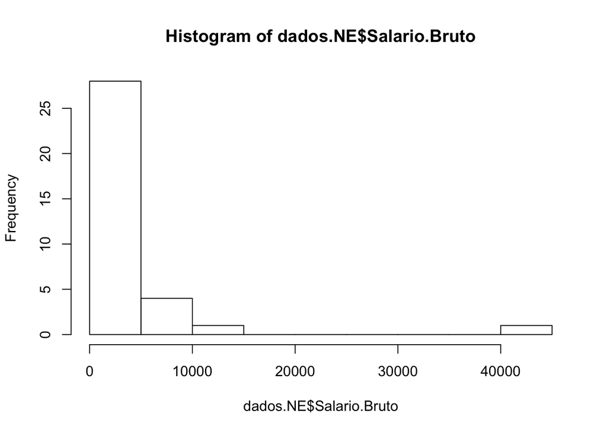

```r
hist(dados.NE$Salario.Bruto);
```

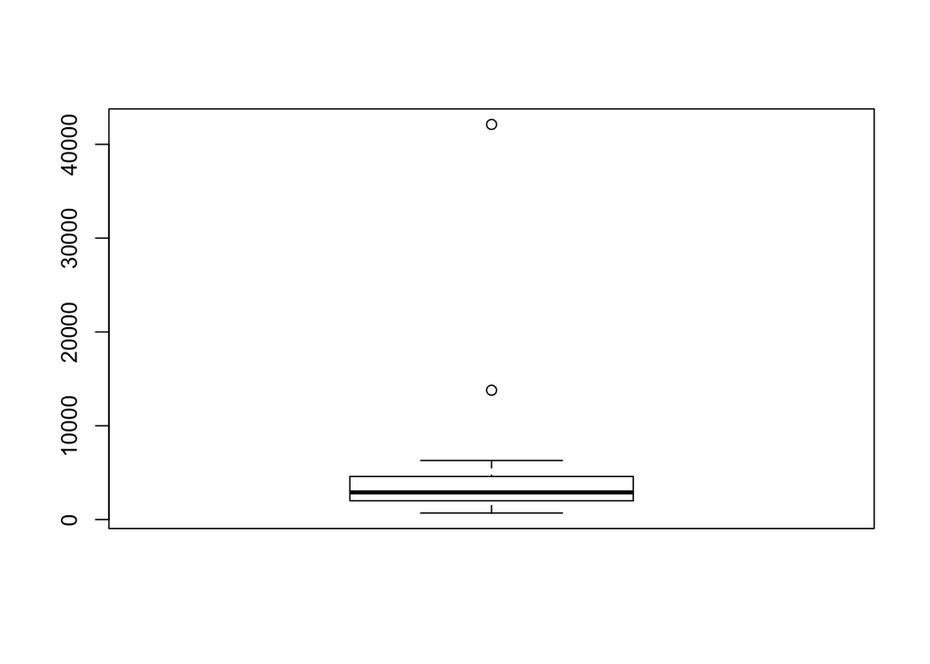

```r
boxplot(dados.NE$Salario.Bruto)
```

```r
#dados relativos a regiao sudeste
dados.SE <- subset(dados, dados$Regiao == "Sudeste");
summary(dados.SE);
```

```
##        X                     Cidade         UF     Salario.Bruto
##  Min.   :  5.00   Belo Horizonte:38   MG     :47   Min.   : 500
##  1st Qu.: 35.50   Rio de Janeiro:16   SP     :25   1st Qu.:2294
##  Median : 82.00   Campinas      :11   RJ     :17   Median :3583
##  Mean   : 80.29   São Paulo     : 9   ES     : 3   Mean   :3962
##  3rd Qu.:121.25   Viçosa        : 4          : 0   3rd Qu.:5500
##  Max.   :162.00   Vitória       : 3   AL     : 0   Max.   :9500
##                   (Other)       :11   (Other): 0
##  Horas.Diarias   Tempo.de.Empresa Experiencia.Profissional
##  Min.   :4.000   Min.   :0.0000   Min.   : 0.000
##  1st Qu.:8.000   1st Qu.:0.9375   1st Qu.: 2.000
##  Median :8.000   Median :1.9550   Median : 4.000
##  Mean   :7.928   Mean   :2.1351   Mean   : 4.659
##  3rd Qu.:8.000   3rd Qu.:3.0000   3rd Qu.: 6.000
##  Max.   :9.000   Max.   :9.0000   Max.   :20.000
##
##    Iniciativa.Privada.ou.Concursado                  Cargo
##                    : 4              Desenvolvimento Java: 6
##  Concursado        : 8              Analista de Sistemas: 4
##  Iniciativa Privada:80              Desenvolvedor Java  : 4
##                                                         : 2
##                                     Analise de Sistemas : 2
##                                     Analista de Negócios: 2
##                                     (Other)             :72
##                                 Formacao  Pos.Graduacao.ou.Certificacao
##  Ciência da Computação              :17   Mode :logical
##                                     :15   FALSE:53
##  Bacharel em Ciência da Computação  :14   TRUE :39
##  Sistemas de Informação             : 4   NA's :0
##  Bacharel em Sistemas de Informações: 3
##  Graduação em Ciência da Computação : 3
##  (Other)                            :36
##           Regiao
##  Centro-oeste: 0
##  Nordeste    : 0
##  Norte       : 0
##  Sudeste     :92
##  Sul         : 0
##
##
```

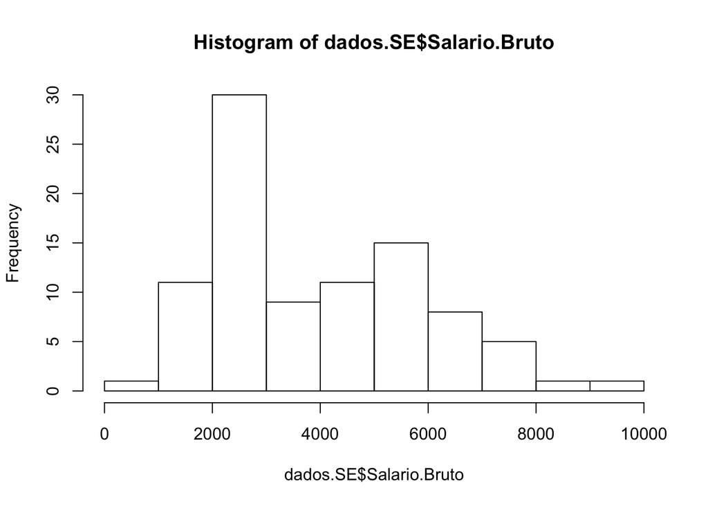

```r
hist(dados.SE$Salario.Bruto);
```

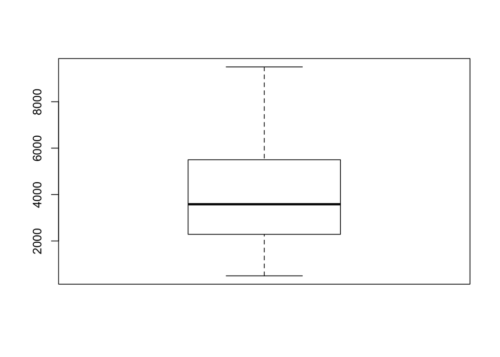

```r
boxplot(dados.SE$Salario.Bruto)
```

```r
dados <- read.csv("salarios-ti-regioes.csv");

regioes <- levels(dados$Regiao);
numRegioes <- length(regioes);


df <- data.frame(Regiao = "Regiao", media.salarios = numeric(numRegioes) );



for(i in 1:numRegioes){
  dadosPorRegiao <- subset(dados, dados$Regiao == regioes[i]);
  mediaSal <- mean(dadosPorRegiao$Salario.Bruto);

df$media.salarios[i] <- mediaSal;
df$Regiao[i][1] <- regioes[i];

}
print(df);
```

```
##   Regiao media.salarios
## 1   <NA>       5620.474
## 2   <NA>       4565.706
## 3   <NA>       2552.500
## 4   <NA>       3962.227
## 5   <NA>       3657.538
```